# drake

9/25/2020

## Technical

- Please clone the repo: https://github.com/kwiscion/drake  
  `git clone https://github.com/kwiscion/drake.git`
- Please install/update packages (`pkgs.R`)
- Please ask questions!
- There will be exercises:
  - `exercieses/*` - start here
  - `solutions/*` - please don’t jump right into here
- Main resource for `drake`: https://books.ropensci.org/drake/index.html
- Contact to me: kwiscion@gmail.com

## Outline

1. Why `drake` - motivation
2. What is `drake` - basics
   - make your first plan
   - get familiar with basic commands
3. Practice `drake` - let’s get deeper
   - track input/output files
   - use batch mode to make your pipeline more reliable
   - use static branching to manage large plans
   - play with some commands
   - use dynamic branching for more flexible plan management

## Why `drake` - motivation

## Why `drake` - motivation

- Track your workflow and rerun only the necesary parts
- Make your workflow reproducible
- Scale your workflow easily
- Keep your workflow tidy
- Retrive history of your analysis

## Warm up - use functions!

Instead of

```r
c <- a + (5 * b)
```

## Warm up - use functions!

Instead of

```r
c <- a + (5 * b)
```

use

```r
f <- function(x, y) {
  x + (5 * y)
}

c <- f(a, b)
```

## Exercise 1

In file `exercises/ex1.R` there is is a “standard” messy analysis.

Please, clean it and rewrite so that every part of the analysis is done by a function.

Keep this values as function parameters:

- input_file <- ‘data/Metro_Interstate_Traffic_Volume.csv’
- gam_k <- -1

## What is `drake` - basics

## What is `drake` - basics

**Plan steps of your process**

```r
plan <- drake_plan(
  a = getA(),
  b = getB(),
  c = f(a, b)
)
```

## What is `drake` - basics

**Plan steps of your process**

```r
plan <- drake_plan(
  a = getA(),
  b = getB(),
  c = f(a, b)
)
```

**Execute them**

```r
make(plan)
```

## What is `drake` - basics

**Plan steps of your process**

```r
plan <- drake_plan(
  a = getA(),
  b = getB(),
  c = f(a, b)
)
```

**Execute them**

```r
make(plan)
```

**And get the results**

```r
readd(c)
```

## Exercise 2

Transform results of Exercise 1 into drake_plan() and execute the plan.

## Exercise 3

Use plan from Exercise 2 and play with it for a while.

- Run `make(plan)` again. Have you noticed any difference?
- Execute `clean()` and run `make(plan)` once again. What happened now?
- Try functions `readd()` and `loadd()` (you need to provide a target(s) name!). What is the difference?
- Visualize dependency graph (`vis_drake_graph(plan)`) and play with it.  
  How do the graph change after you clean one of the targets? And after you run `make(plan, 'model')`?
- Remove one of terms from GAM model (make sure to source the function!). What was the impact on plan? Check `vis_drake_graph(plan)` and `outdated(plan)`.
- Edit input file by hand. What happened?

## Practice `drake` - let’s get deeper

## Track input/output files

- `file_in` - for input file
- `file_out` - for output file
- `knitr_in` - for R Markdown reports

**Example:**

```r
drake_plan(
  data = read.csv(file_in('input.csv'))
  ...
)
```

## Exercise 4

Use plan from Exercise 2 and:

- Add input file tracking to the plan
- Add to the plan rendering of `report.Rmd` to `report.html` (Hint: Use `rmarkdown::render()`, `kintr_in()` and `file_out()`)
- Test what happens to the plan after modification to input file or removal of rendered report (html file)

## Make your workflow reproducible

**Project structure**

```r
 ./
 |_ R/
 |  |_ config.R
 |  |_ functions.R
 |  |_ packages.R
 |  |_ plan.R
 |
 |_ _drake.R
```

## Make your workflow reproducible

**`_drake.R`**

```r
source('R/packages.R')
source('R/functions.R')
source('R/config.R')
source('R/plan.R')

drake_config(plan, verbose = 2L)
```

## Exercise 5

**Make your pipeline more robust.**

- `_drake.R`
- `R/packages.R`
- `R/functions.R`
- `R/config.R`
- `R/plan.R`

Now test `r_make()` and other `r_*()` functions.

## Static branching

**Multiple parameter values - wrong way**

```r
drake_plan(
  ...
  rf_10 = fitRandomForest(data, trees = 10),
  rf_100 = fitRandomForest(data, trees = 100),
  rf_1000 = fitRandomForest(data, trees = 1000),
  model_summary_10 = summary(rf_10),
  model_summary_100 = summary(rf_100),
  model_summary_1000 = summary(rf_1000),
  ...
)
```

## Static branching

**Multiple parameter values - wrong way**

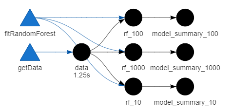

## Static branching

**Multiple parameter values - right way**

```r
drake_plan(
  ...
  rf = target(fitRandomForest(data, trees = trees),
              transform = map(trees = c(10, 100, 1000)),

  model_summary = target(summary(rf),
                         transform = map(rf)),
  ...
)
```

## Static branching

**Multiple parameter values - right way**

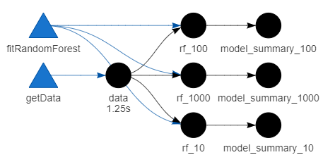

## Static branching

**Multiple parameter values - right way**

```r
param <-  c(10, 100, 1000))

drake_plan(
  ...
  rf = target(fitRandomForest(data, trees = trees),
              transform = map(trees = !! param,

  model_summary = target(summary(rf),
                         transform = map(rf)),
  ...
)
```

## Exercise 6

Test few `gam_k` parameter values.

- Use `map()` to parametrize targets affected
- For simplicity, please remove report rendering

**BONUS TASK:** Try modifying the report (both `report.Rmd` and rendering function) to make it work with branching (HINT: `id_chr()` gives current target name)

## Static branching

**Available transformations:**

- `map()` - iterate over parameters simulatouslt
- `split()` - distribute data uniformly across subtargets
- `cross()` - crossproduct of parameters
- `combine()` - combine multiple subtargets into one

## Exercise 7

Combine test set predictions targets into a single target.

HINT: use `bind_rows()`

## Exercise 8

**Play with `drake` a bit more**

- Set `map(gam_k = c(-1, 3, 5, 8, 10, 15))` and test `max_expand` argument of `drake_plan()`
- Check what `build_times()` and `predict_runtime(plan)` do
- Check what `drake_history()` does
- Use some `hash` obtained from `drake_history()` to retrive targer from `drake_cache()`  
  HINT: Use `drake_cache()$get_value()`
- Try debuging one of the targets  
  HINT: Use `drake_debug()`

## Dynamic branching

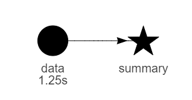

```r
drake_plan(
  data = iris %>% split(.$Species),

  summary = target(summary(data),
                   dynamic = map(data)),
)
```

## Exercise 9

Use dynamic branching to prepare separate model for each `day_type`

- use `split()` inside data preprocessing to create separate subtarger for each day_type
- in next target(s) use `dynamic = map(...)` for iteration over subtargets
- HINT: In plan, change data to data[[1]]